# GTI - Banco de dados - 2025 - Anotações de aula

Professor Miguél Suares

2025-07-30

# Sobre estas anotações

—————————————————————————————————————————————

Estas anotações são apenas lembretes das aulas expostas em sala, durante a disciplina de Banco de dados.

## 0.1 ACESSO AO GITBOOK CELULAR

—————————————————————————————————————————————

#### 0.1.0.1 https://miguel7penteado.github.io/2025-2sem-GTI-BancoDeDados

[figure not shown]

## 0.2 Leitores de formato de arquivo EPUB para SmartPhone

—————————————————————————————————————————————

### 0.2.1 ANDROID

#### 0.2.1.1 **Moon+ Reader**

[figure not shown]

## 0.3 Livros Texto da Disciplina

—————————————————————————————————————————————

### 0.3.1 “Introdução a sistemas de bancos de dados” do autor “**Christopher John Date**”

[figure not shown]

**Autor(es)**

### [**Christopher John Date**](https://en.wikipedia.org/wiki/Christopher_J._Date)

**Editora**

LTC

**Idioma**

Português

**ISBN**

978-85-352-8445-4

**Formato**

Capa dura

**Páginas**

1623

### 0.3.2 [“**Projeto de bancos de dados**” do autor “Carlos Alberto HEUSER”](https://drive.google.com/file/d/0B452rmbcudPSVFdCZ09vVkJUUUd2dlpMNS1vaEczUQ/view?pli=1&resourcekey=0-3MTcHlAYjPX6YSvBQGweUQ)

[figure not shown]

**Autor(es)**

### [Carlos Alberto HEUSER](https://www.inf.ufrgs.br/site/docente/carlos-alberto-heuser/)

**Editora**

Bookman

**Idioma**

Português

**ISBN-10**

8577803821

**Formato**

Impresso

**Páginas**

282

## 0.4 Calendário das aulas

—————————————————————————————————————————————

##### 0.4.0.0.1 AGOSTO DE 2025

| Data | Dia da Semana | Aulas | Conteúdo |
| --- | --- | --- | --- |
| 04/08/2025 | Segunda-Feira | Aula Inaugural |  |
| 11/08/2025 | Segunda-Feira | Aula 2 |  |
| 18/08/2025 | Segunda-Feira | Aula 3 |  |
| 25/08/2025 | Segunda-Feira | Aula 4 |  |

##### 0.4.0.0.2 SETEMBRO DE 2025

| Data | Dia da Semana | Aulas | Conteúdo |
| --- | --- | --- | --- |
| 01/09/2025 | Segunda-Feira | Aula 5 |  |
| 08/09/2025 | Segunda-Feira | Aula 6 |  |
| 15/09/2025 | Segunda-Feira | NP1 | PROVA |
| 22/09/2025 | Segunda-Feira | Aula 7 |  |
| 29/09/2025 | Segunda-Feira | Aula 8 |  |

##### 0.4.0.0.3 OUTUBRO DE 2025

| Data | Dia da Semana | Aulas | Conteúdo |
| --- | --- | --- | --- |
| 06/10/2025 | Segunda-Feira | Aula 9 |  |
| 13/10/2025 | Segunda-Feira | Aula 10 |  |
| 20/10/2025 | Segunda-Feira | Aula 11 |  |
| 27/10/2025 | Segunda-Feira | Aula 12 |  |

##### 0.4.0.0.4 NOVEMBRO DE 2025

| Data | Dia da Semana | Aulas | Conteúdo |
| --- | --- | --- | --- |
| 03/11/2025 | Segunda-Feira | NP2 | PROVA |
| 10/11/2025 | Segunda-Feira |  | N/A |
| 17/11/2025 | Segunda-Feira | SUB | PROVA |
| 24/11/2025 | Segunda-Feira |  | N/A |

##### 0.4.0.0.5 DEZEMBRO DE 2025

| Data | Dia da Semana | Aulas | Conteúdo |
| --- | --- | --- | --- |
| 01/12/2025 | Segunda-Feira |  | N/A |
| 08/12/2025 | Segunda-Feira | EXAME | PROVA |
| 15/12/2025 | Segunda-Feira |  | N/A |

## 0.5 Alunos 2025 - 2o Semestre

—————————————————————————————————————————————

### 0.5.1 Campus Chácara Santo Antônio

#### 0.5.1.1 Turma TI2P40

| Matrícula | Nome do aluno |
| --- | --- |
| F362BF0 | BRUNO ANTONIO MARQUES |
| R536FA6 | CAIO CESAR BALBINO DA SILVA |
| H6094I1 | DOUGLAS VINICIUS M DOS SANTOS |
| R6607G5 | GABRIEL ROQUE DOS SANTOS |
| R8133G7 | ÍTALO KEVIN RODRIGUES DA SILVA |
| R837AA0 | LUCAS SOUZA RODRIGUES |
| H714419 | MARCOS PAULO CORDEIRO GOES |

# 1 Hello bookdown

## 1.1 A section

All chapter sections start with a second-level (`##`) or higher heading followed by your section title, like the sections above and below here. You can have as many as you want within a chapter.

### An unnumbered section

Chapters and sections are numbered by default. To un-number a heading, add a `{.unnumbered}` or the shorter `{-}` at the end of the heading, like in this section.

# 2 Cross-references

Cross-references make it easier for your readers to find and link to elements in your book.

## 2.1 Chapters and sub-chapters

There are two steps to cross-reference any heading:

1. Label the heading: `# Hello world {#nice-label}`.
   - Leave the label off if you like the automated heading generated based on your heading title: for example, `# Hello world` = `# Hello world {#hello-world}`.
   - To label an un-numbered heading, use: `# Hello world {-#nice-label}` or `{# Hello world .unnumbered}`.
2. Next, reference the labeled heading anywhere in the text using `\@ref(nice-label)`; for example, please see Chapter 2.
   - If you prefer text as the link instead of a numbered reference use: any text you want can go here.

## 2.2 Captioned figures and tables

Figures and tables *with captions* can also be cross-referenced from elsewhere in your book using `\@ref(fig:chunk-label)` and `\@ref(tab:chunk-label)`, respectively.

See Figure 2.1.

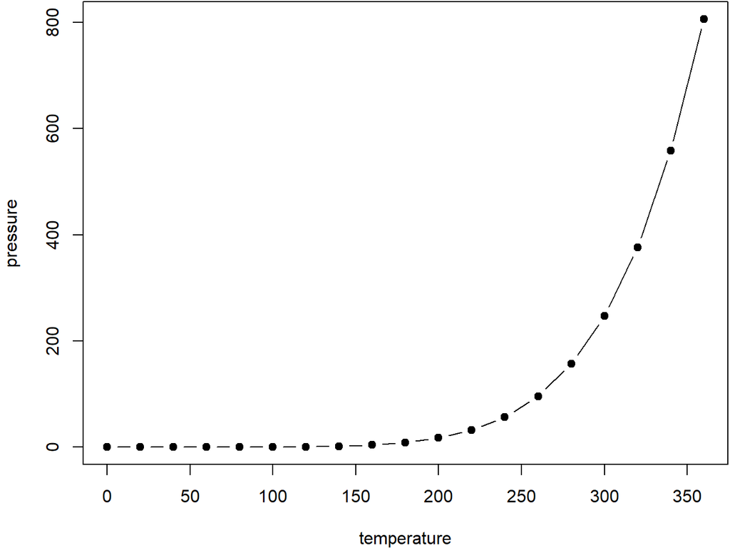

Figure 2.1: Here is a nice figure!

```r
par(mar = c(4, 4, .1, .1))
plot(pressure, type = 'b', pch = 19)
```

Don’t miss Table 2.1.

```r
knitr::kable(
  head(pressure, 10), caption = 'Here is a nice table!',
  booktabs = TRUE
)
```

Table 2.1: Here is a nice table!

| temperature | pressure |
| --- | --- |
| 0 | 0.0002 |
| 20 | 0.0012 |
| 40 | 0.0060 |
| 60 | 0.0300 |
| 80 | 0.0900 |
| 100 | 0.2700 |
| 120 | 0.7500 |
| 140 | 1.8500 |
| 160 | 4.2000 |
| 180 | 8.8000 |

# 3 Parts

You can add parts to organize one or more book chapters together. Parts can be inserted at the top of an .Rmd file, before the first-level chapter heading in that same file.

Add a numbered part: `# (PART) Act one {-}` (followed by `# A chapter`)

Add an unnumbered part: `# (PART\*) Act one {-}` (followed by `# A chapter`)

Add an appendix as a special kind of un-numbered part: `# (APPENDIX) Other stuff {-}` (followed by `# A chapter`). Chapters in an appendix are prepended with letters instead of numbers.

# 4 Footnotes and citations

## 4.1 Footnotes

Footnotes are put inside the square brackets after a caret `^[]`. Like this one [^1].

## 4.2 Citations

Reference items in your bibliography file(s) using `@key`.

The RStudio Visual Markdown Editor can also make it easier to insert citations: https://rstudio.github.io/visual-markdown-editing/#/citations

# 5 Blocks

## 5.1 Equations

Here is an equation.

$$\begin{equation}
f\left(k\right) = \binom{n}{k} p^k\left(1-p\right)^{n-k}
\tag{5.1}
\end{equation}$$

You may refer to using `\@ref(eq:binom)`, like see Equation (5.1).

## 5.2 Theorems and proofs

**Theorem 5.1** For a right triangle, if $c$ denotes the *length* of the hypotenuse and $a$ and $b$ denote the lengths of the **other** two sides, we have
$$a^2 + b^2 = c^2$$

Read more here https://bookdown.org/yihui/bookdown/markdown-extensions-by-bookdown.html.

# 6 Sharing your book

## 6.1 Publishing

HTML books can be published online, see: https://bookdown.org/yihui/bookdown/publishing.html

## 6.2 404 pages

By default, users will be directed to a 404 page if they try to access a webpage that cannot be found. If you’d like to customize your 404 page instead of using the default, you may add either a `_404.Rmd` or `_404.md` file to your project root and use code and/or Markdown syntax.

## 6.3 Metadata for sharing

Bookdown HTML books will provide HTML metadata for social sharing on platforms like Twitter, Facebook, and LinkedIn, using information you provide in the `index.Rmd` YAML. To setup, set the `url` for your book and the path to your `cover-image` file. Your book’s `title` and `description` are also used.

This `gitbook` uses the same social sharing data across all chapters in your book- all links shared will look the same.

Specify your book’s source repository on GitHub using the `edit` key under the configuration options in the `_output.yml` file, which allows users to suggest an edit by linking to a chapter’s source file.

Read more about the features of this output format here:

https://pkgs.rstudio.com/bookdown/reference/gitbook.html

Or use:

```r
?bookdown::gitbook
```

# References

Xie, Yihui. 2015. *Dynamic Documents with R and Knitr*. 2nd ed. Boca Raton, Florida: Chapman; Hall/CRC. http://yihui.org/knitr/.

[^1]: This is a footnote.